# Stat 115 Lab 10

GWAS, Regression, Feature Selection

Yushi Tang

April 9/11, 2019

## Anouncements

- HW5 is due on April 14, 2019 @ 11:59 pm
- Additional office hour on this Friday 11:30 am - 12:30 pm @ HSPH Building 2 Room 428

## Outline

- Genome-Wide Association Study (GWAS)
  - Building blocks for a complete GWAS
  - General procedure
  - Other technique details
- Regression and Feature Selection
  - Mathematical details
  - Examples
  - Cheer for experiences

## Install and Load Packages

```r
install.packages("glmnet")
```

```r
library(glmnet)
library(ggplot2)
```

## Part I: Genome-Wide Association Study (GWAS)

- From genetic variation to phenotypic variation
- Mapping?
- Connection between genotype and phenotype!
- Genotype: Pair of alleles at a locus
  - e.g. AA, Aa, aa
  - Heterozygote (Aa), Homozygote (AA and aa)
- Phenotype: A specific trait or an observable characteristic

## Linkage Disequilibrium (LD) Analysis

- Haploview:
  - http://www.broadinstitute.org/haploview/haploview
  - choosing tag SNPs
- SNAP:
  - http://www.broadinstitute.org/mpg/snap/
  - choosing proxies of the tag SNPs
- FUGUE (Frequency Using Graphs based on EM Algorithm):
  - http://csg.sph.umich.edu/yli/software.html
  - computing D’ and $R^2$ using genotype data

## Haplotype Inference

- FUGUE (Frequency Using Graphs based on EM Algorithm):
  - http://csg.sph.umich.edu/yli/software.html
  - estimating haplotype frequency based on genotype data
- MACH (Markov Chain based Haplotyper):
  - http://csg.sph.umich.edu/abecasis/MaCH/
  - estimating most likely haplotype based on genotype data

## Data Quality Control (QC)

- PLINK:
  - https://www.cog-genomics.org/plink/2.0/
  - plink.lmiss/plink.vmiss: removing SNPs with large missing rate
  - removing SNPs that violate HWE
  - removing SNPs with extremely small minor allele frequency (MAF)
- Still debating:
  - Other indicators of good quality for considering
    - how to test the HWE more accurate
    - combined depth of specific allele
    - ratio of transitions over transversions
    - ratio of heterozygous over homozygous variance
    - ratio of insertion over deletion

## Measuring the Connection (Association Analysis)

- The case-control genetic association studies for most settings
- A glance of the data

[output not shown]

## Measuring the Connection (Association Analysis)

- PLINK:
  - https://www.cog-genomics.org/plink/2.0/
  - estimating the association between a quantitative trait and mutations
  - plink.glm.linear: conduct linear regression
  - plink.glm.logistic: conduct logistic regression
- Armitage Trend Test (ATT) for Association Testing
  - often used as genotype-based test for case-control genetic association studies
  - a glance of ATT data

$$\chi^2 = N\times \{r(G,P)\}^2$$

## Other Issues

- Fine-mapping and SNPs imputation (when we do not have WGS data)
- Considering population structure
  - Measuring population distance: $F_{ST}$
- Adjusting population stratification bias
  - How to measure this bias?
  - Q-Q plot and $\lambda_{GC}$
  - PCA: a solution for population stratification
  - Using Mixed Model Association to adjust
- Controling sample relatedness
  - How to measure relatedness?
  - Kinship matrix for now (https://brainder.org/2015/07/29/understanding-the-kinship-matrix/)
  - Potential problems
  - Correct cryptic relatedness / family relatedness (Mixed Model Association)
- Phenotype inference based on genotype data
  - e.g.1 sex inference
  - e.g.2 ethnicity inference
- …
- All techniques above could all be done with python

## Reconsidering the Causal Procedure within the Connection

- Incorporating epigenetic scores/ functional annotation results to improve the power of GWAS
  - HaploReg: https://pubs.broadinstitute.org/mammals/haploreg/haploreg.php
    - Annotate SNP with chromatin state
    - Add the protein binding annotation
    - Annotation information comes from the Roadmap Epigenomics and ENCODE projects
  - RegulomeDB: http://regulome.stanford.edu/
    - Identify DNA features in non-coding regions
    - Detect regulatory elements in non-coding regions
    - Regions of DNAase hypersensitivity
    - Binding sites of transcription factors
    - Promoter regions that have been biochemically characterized to regulation transcription.
- Incorporating DNA-methylation
- Incorporating DNA 3D shape parameters
- Incorporating higher-order chromatin structure
- Other informational epigenomic factors (over 200)

## Part II: Regression and Feature Selection

- Objective: find best-fit line to data.
- For each subject $i$, observe outcome $Y_i$ and vector of covariates $X_i$.
- Mathematical details: try to obtain $\boldsymbol{\beta}$ that could minimize
  $$\sum_{i = 1}^n (Y_i - X_i \beta)^2$$
  $$\hat{\beta} = (X^T X)^{-1} X^T Y$$

```r
# 1 covariate
model_1 <- lm(mpg ~ wt, data = mtcars)
summary(model_1)
```

```
##
## Call:
## lm(formula = mpg ~ wt, data = mtcars)
##
## Residuals:
##     Min      1Q  Median      3Q     Max
## -4.5432 -2.3647 -0.1252  1.4096  6.8727
##
## Coefficients:
##             Estimate Std. Error t value Pr(>|t|)
## (Intercept)  37.2851     1.8776  19.858  < 2e-16 ***
## wt           -5.3445     0.5591  -9.559 1.29e-10 ***
## ---
## Signif. codes:  0 '***' 0.001 '**' 0.01 '*' 0.05 '.' 0.1 ' ' 1
##
## Residual standard error: 3.046 on 30 degrees of freedom
## Multiple R-squared:  0.7528, Adjusted R-squared:  0.7446
## F-statistic: 91.38 on 1 and 30 DF,  p-value: 1.294e-10
```

```r
# set the intercept as 0
model_2 <- lm(mpg ~ wt - 1, data = mtcars)
summary(model_2)
```

```
##
## Call:
## lm(formula = mpg ~ wt - 1, data = mtcars)
##
## Residuals:
##      Min       1Q   Median       3Q      Max
## -18.3018  -3.3177   0.7468   7.7538  24.1899
##
## Coefficients:
##    Estimate Std. Error t value Pr(>|t|)
## wt   5.2916     0.5932   8.921 4.55e-10 ***
## ---
## Signif. codes:  0 '***' 0.001 '**' 0.01 '*' 0.05 '.' 0.1 ' ' 1
##
## Residual standard error: 11.27 on 31 degrees of freedom
## Multiple R-squared:  0.7197, Adjusted R-squared:  0.7106
## F-statistic: 79.58 on 1 and 31 DF,  p-value: 4.553e-10
```

```r
# multiple covariates
model_3 <- lm(mpg ~ wt + cyl, data = mtcars)
summary(model_3)
```

```
##
## Call:
## lm(formula = mpg ~ wt + cyl, data = mtcars)
##
## Residuals:
##     Min      1Q  Median      3Q     Max
## -4.2893 -1.5512 -0.4684  1.5743  6.1004
##
## Coefficients:
##             Estimate Std. Error t value Pr(>|t|)
## (Intercept)  39.6863     1.7150  23.141  < 2e-16 ***
## wt           -3.1910     0.7569  -4.216 0.000222 ***
## cyl          -1.5078     0.4147  -3.636 0.001064 **
## ---
## Signif. codes:  0 '***' 0.001 '**' 0.01 '*' 0.05 '.' 0.1 ' ' 1
##
## Residual standard error: 2.568 on 29 degrees of freedom
## Multiple R-squared:  0.8302, Adjusted R-squared:  0.8185
## F-statistic: 70.91 on 2 and 29 DF,  p-value: 6.809e-12
```

## LASSO

- Linear regression deals with limited number of covariates
- What if we have a huge amount of covariates?
- Lasso for variable selection!
- Penalize $\beta$ for being too big.
- Try to obtain $\boldsymbol{\beta}$ and $\lambda$ that could minimize

$$\sum_{i = 1}^n (Y_i - X_i \beta)^2 + \lambda \sum_{j = 1}^p |\beta_j|$$

- Remember to normalize your data! The unit of the data would matter a lot.
  - The magnitude of the coefficient would be changed
  - e.g. Distance measured in km or m

## LASSO in R

```r
data(QuickStartExample) # from glmnet package
head(x, 3)
```

```
##            [,1]       [,2]       [,3]       [,4]       [,5]      [,6]
## [1,]  0.2738562 -0.0366722  0.8547269  0.9675242  1.4154898 0.5234059
## [2,]  2.2448169 -0.5460300  0.2340651 -1.3350304  1.3130758 0.5212746
## [3,] -0.1254230 -0.6068782 -0.8539217 -0.1487772 -0.6646828 0.6066164
##            [,7]       [,8]       [,9]     [,10]      [,11]       [,12]
## [1,]  0.5626882  1.1112233  1.6408214 0.6187067  0.9999348 -0.07841916
## [2,] -0.6100346 -0.8613965 -0.2704635 0.2300825 -0.1057090  0.16314122
## [3,]  0.1617207 -0.8627217  0.6042102 1.1939768  0.5012509 -0.94520592
##           [,13]       [,14]      [,15]      [,16]      [,17]       [,18]
## [1,] -0.6033261  0.03323168 -0.7008845  1.1578379  1.4578156  0.77490699
## [2,]  0.7620766  0.67812003 -0.5282670 -0.8791548 -0.4729134 -1.11717309
## [3,]  0.3989026 -0.76478505  1.2854019  0.6448767  0.1792455  0.04473756
##           [,19]      [,20]
## [1,] -1.2685177  1.9935800
## [2,] -0.7377321 -1.0787929
## [3,]  1.1053071  0.3040545
```

```r
head(y)
```

```
##            [,1]
## [1,] -1.2748860
## [2,]  1.8434251
## [3,]  0.4592363
## [4,]  0.5640407
## [5,]  1.8729633
## [6,]  0.5275317
```

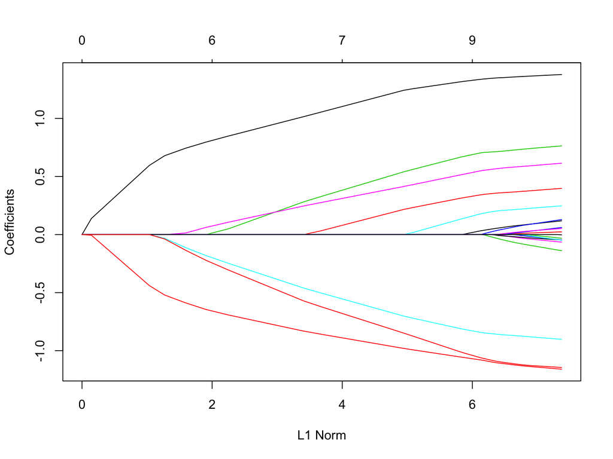

```r
fit <- glmnet(x, y) # Fit the GLM with LASSO
plot(fit)
```

```r
coef(fit, s = 0.1) # s indicates the lambda value. Every value with a '.' means a 0.
```

```
## 21 x 1 sparse Matrix of class "dgCMatrix"
##                        1
## (Intercept)  0.150928072
## V1           1.320597195
## V2           .
## V3           0.675110234
## V4           .
## V5          -0.817411518
## V6           0.521436671
## V7           0.004829335
## V8           0.319415917
## V9           .
## V10          .
## V11          0.142498519
## V12          .
## V13          .
## V14         -1.059978702
## V15          .
## V16          .
## V17          .
## V18          .
## V19          .
## V20         -1.021873704
```

## Picking $\lambda$: Cross-Validation

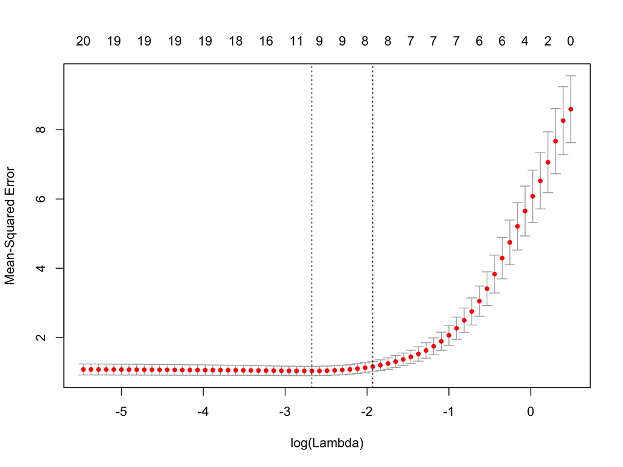

```r
cvfit <- cv.glmnet(x, y) # We do not have exact equation to pick lambda. One efficient way of picking lambda is cross-validation. So actually, this is a cross validation (cv) process. The default value for cross might be 5, which is supposed to be checked.
plot(cvfit)
```

```r
# min lambda
cvfit$lambda.min
```

```
## [1] 0.06896889
```

```r
# coefficients for min lambda
coef(cvfit, s = "lambda.min")
```

```
## 21 x 1 sparse Matrix of class "dgCMatrix"
##                        1
## (Intercept)  0.147927056
## V1           1.337393911
## V2           .
## V3           0.704086480
## V4           .
## V5          -0.842853149
## V6           0.549403480
## V7           0.032703914
## V8           0.342430521
## V9           .
## V10          0.001206607
## V11          0.178995989
## V12          .
## V13          .
## V14         -1.079993473
## V15          .
## V16          .
## V17          .
## V18          .
## V19          .
## V20         -1.061382443
```

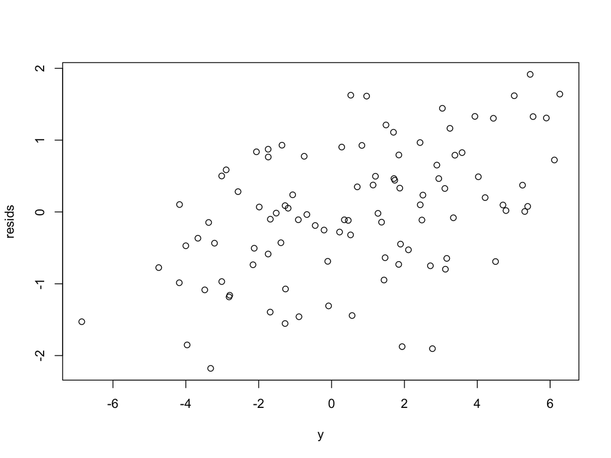

```r
# residuals for min lambda (This might be useful for homework to get residuals)
resids <- y - predict(cvfit, newx = x, s = "lambda.min")
plot(y, resids)
```